# Predicting Marital Status - Exploratory Data Analysis

Rachel Kalusniak

2023-04-24

Below are the libraries you want to install for this project. `ggh4x` is a new package I discovered on [this Stack Overflow post](https://stackoverflow.com/questions/3685285/ggplot2-facet-grid-free-scales). This extension of ggplot2 allows for additional axis manipulation on faceted plots. Please be careful installing this. It created an issue with my device, and I had to reinstall `rlang` and `ggplot2`, in that order.

```r
library(dplyr)
library(skimr)
```

```r
library(tidyr)
library(ggplot2)
#install.packages('ggh4x')
library(ggh4x)
library(RColorBrewer)
library(scales)
library(corrplot)
```

## Getting Started

Let’s load the data cleaned in the previous markdown file.

```r
nlsy97 <- readRDS('Data/clean_nlsy97.Rds')
```

In the previous file, I checked the overall set-up of the data with the `skim()` package. I now want to look more closely to see what insights are available.

```r
skim(nlsy97)
```

Data summary

| Name | nlsy97 |
| --- | --- |
| Number of rows | 8832 |
| Number of columns | 37 |
| _______________________ |  |
| Column type frequency: |  |
| Date | 1 |
| factor | 20 |
| numeric | 16 |
| ________________________ |  |
| Group variables | None |

**Variable type: Date**

| skim_variable | n_missing | complete_rate | min | max | median | n_unique |
| --- | --- | --- | --- | --- | --- | --- |
| BDAY | 0 | 1 | 1980-01-01 | 1984-12-01 | 1982-07-01 | 60 |

**Variable type: factor**

| skim_variable | n_missing | complete_rate | ordered | n_unique | top_counts |
| --- | --- | --- | --- | --- | --- |
| HEALTH_1997 | 5 | 1.00 | FALSE | 5 | exc: 3425, ver: 2983, goo: 1970, fai: 422 |
| WEIGHTPRECEP_1997 | 21 | 1.00 | FALSE | 5 | abo: 5042, sli: 2003, sli: 1098, ver: 377 |
| WEIGHTCHANGE_1997 | 18 | 1.00 | FALSE | 4 | los: 3324, sta: 2119, not: 1878, gai: 1493 |
| RACE | 0 | 1.00 | FALSE | 4 | non: 4602, bla: 2297, his: 1853, mix: 80 |
| WEIGHTPRECEP_2008 | 1626 | 0.82 | FALSE | 5 | abo: 3128, sli: 2687, ver: 720, sli: 604 |
| WEIGHTCHANGE_2008 | 1638 | 0.81 | FALSE | 4 | los: 3252, not: 1617, sta: 1567, gai: 758 |
| HEALTH_2008 | 1483 | 0.83 | FALSE | 5 | ver: 2665, goo: 2181, exc: 1843, fai: 600 |
| HEALTH_2019 | 2025 | 0.77 | FALSE | 5 | ver: 2456, goo: 2155, exc: 1395, fai: 693 |
| GED | 0 | 1.00 | FALSE | 2 | 0: 7733, 1: 1099 |
| HS | 0 | 1.00 | FALSE | 2 | 1: 6641, 0: 2191 |
| AA | 0 | 1.00 | FALSE | 2 | 0: 7705, 1: 1127 |
| BA | 0 | 1.00 | FALSE | 2 | 0: 6536, 1: 2296 |
| PROF | 0 | 1.00 | FALSE | 2 | 0: 8708, 1: 124 |
| PHD | 0 | 1.00 | FALSE | 2 | 0: 8771, 1: 61 |
| MA | 0 | 1.00 | FALSE | 2 | 0: 8179, 1: 653 |
| FEMALE | 0 | 1.00 | FALSE | 2 | 0: 4526, 1: 4306 |
| BOTHPARENTS_1997 | 1136 | 0.87 | FALSE | 2 | 0: 4223, 1: 3473 |
| COHAB_PREMARRY | 0 | 1.00 | FALSE | 2 | 1: 5602, 0: 3230 |
| FAILMARRY | 4125 | 0.53 | FALSE | 2 | 0: 3321, 1: 1386 |
| NEVERMARRY | 2055 | 0.77 | FALSE | 2 | 0: 4078, 1: 2699 |

**Variable type: numeric**

| skim_variable | n_missing | complete_rate | mean | sd | p0 | p25 | p50 | p75 | p100 | hist |
| --- | --- | --- | --- | --- | --- | --- | --- | --- | --- | --- |
| PUBID_1997 | 0 | 1.00 | 4499.60 | 2602.33 | 1.00 | 2241.75 | 4496.50 | 6742.25 | 9022.00 | ▇▇▇▇▇ |
| WEIGHT_1997 | 269 | 0.97 | 132.26 | 33.52 | 4.00 | 110.00 | 128.00 | 150.00 | 390.00 | ▁▇▂▁▁ |
| INCOME_1997 | 2354 | 0.73 | 46401.62 | 42098.07 | -48100.00 | 18000.00 | 37750.00 | 61300.00 | 246474.00 | ▂▇▂▁▁ |
| HHSIZE_1998 | 593 | 0.93 | 4.42 | 1.56 | 1.00 | 3.00 | 4.00 | 5.00 | 15.00 | ▃▇▁▁▁ |
| ASVAB | 1850 | 0.79 | 45413.89 | 29203.09 | 0.00 | 19363.00 | 43084.50 | 70203.75 | 100000.00 | ▇▆▆▆▅ |
| INCOME_2008 | 2522 | 0.71 | 60249.33 | 58810.55 | 0.00 | 22325.00 | 45240.00 | 77237.50 | 313703.00 | ▇▃▁▁▁ |
| WEIGHT_2008 | 1662 | 0.81 | 178.77 | 46.67 | 5.00 | 145.00 | 171.00 | 200.00 | 460.00 | ▁▇▅▁▁ |
| INCOME_2019 | 3515 | 0.60 | 92740.70 | 85754.43 | 0.00 | 39000.00 | 75000.00 | 120000.00 | 467966.00 | ▇▃▁▁▁ |
| WEIGHT_2019 | 2114 | 0.76 | 190.78 | 49.07 | 92.00 | 155.00 | 184.00 | 218.00 | 500.00 | ▆▇▂▁▁ |
| GRADESREPEAT | 2985 | 0.66 | 0.24 | 0.53 | 0.00 | 0.00 | 0.00 | 0.00 | 4.00 | ▇▂▁▁▁ |
| GRADESSKIP | 2958 | 0.67 | 0.03 | 0.18 | 0.00 | 0.00 | 0.00 | 0.00 | 3.00 | ▇▁▁▁▁ |
| WKSWK_ADULT | 857 | 0.90 | 598.13 | 292.30 | 0.00 | 395.00 | 684.00 | 827.00 | 1054.00 | ▃▃▃▇▅ |
| HIGHGRADE | 99 | 0.99 | 13.88 | 4.82 | 0.00 | 12.00 | 14.00 | 16.00 | 95.00 | ▇▁▁▁▁ |
| HEIGHTIN_2008 | 1638 | 0.81 | 67.52 | 4.30 | 34.00 | 64.00 | 67.00 | 71.00 | 92.00 | ▁▁▇▆▁ |
| MARRYAGE | 4125 | 0.53 | 26.05 | 4.85 | 12.74 | 22.24 | 25.48 | 29.40 | 39.47 | ▁▇▇▅▂ |
| COHABAGE | 3225 | 0.63 | 22.93 | 4.45 | 12.41 | 19.48 | 22.15 | 25.57 | 38.89 | ▁▇▅▂▁ |

Looking at the yearly data, an increasing number of missing values in 2008 and even more in 2019. This indicates that more participants are dropping out the the survey as time passes. This is expected, but it should not prevent model building. The 2019 income values and marriage failure indicator have the lowest completion rate. Marriage failure only applies to subset of the population that ever got married, so its actual completion rate likely is much higher.

There are some interesting insights in the categorical variables. At a glance, the individuals in excellent or very good health decreased overtime. I do not see any obvious trends in the subject’s weight goals at this zoomed out level, but the proportion of subjects that feel their weight is “about right” decreased significantly between the subject’s teen years and mid-20s. This speaks to a body dismorphia issue for other research. The number of subjects that achieve a degree decreases as the degree level increases. This makes logical sense, but it may mean that higher levels of academic achievement may have limited use for modeling because they don’t have enough representation.

## Overall Target Variables

```r
g_overall <- nlsy97 %>%
  select(NEVERMARRY, FAILMARRY) %>%
  pivot_longer(c(NEVERMARRY, FAILMARRY), names_to = 'VARIABLE', values_to = 'VALUE') %>%
  group_by(VARIABLE) %>%
  summarize(count = sum(!is.na(VALUE)),
            YES = mean(as.numeric(as.character(VALUE)), na.rm = TRUE)) %>%
  mutate(NO = 1 - YES)

nm_true_overall <- g_overall[2, 'YES']
div_true_overall <- g_overall[1, 'YES']

g_overall
```

```
## # A tibble: 2 × 4
##   VARIABLE   count   YES    NO
##   <chr>      <int> <dbl> <dbl>
## 1 FAILMARRY   4707 0.294 0.706
## 2 NEVERMARRY  6777 0.398 0.602
```

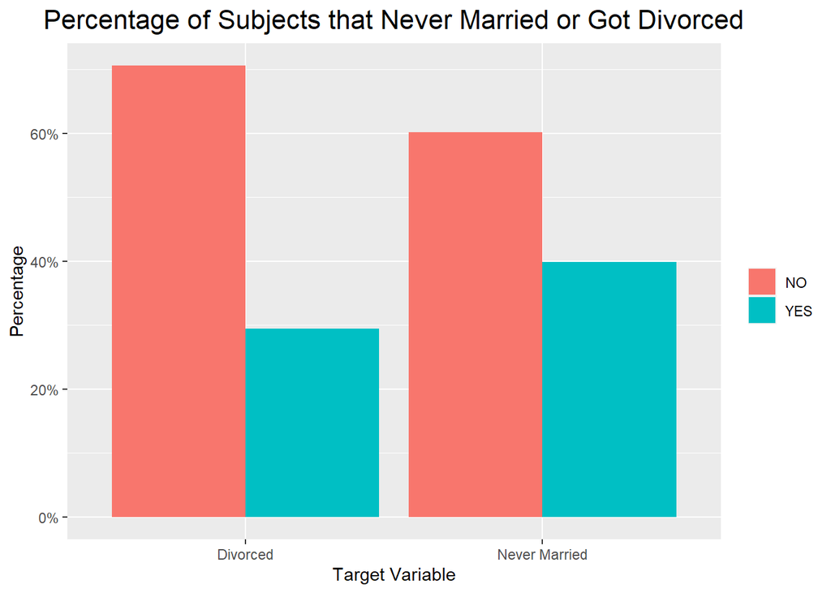

```r
g_overall %>%
  select(-count) %>%
  pivot_longer(c('YES', 'NO'), names_to = 'YN', values_to = "pct") %>%
  ggplot(aes(x = VARIABLE, y = pct, fill = YN)) +
  geom_col(position = 'dodge') +
  scale_y_continuous(labels = percent) +
  scale_x_discrete(labels = c('Divorced','Never Married')) +
  labs(y = 'Percentage', x = 'Target Variable') +
  ggtitle('Percentage of Subjects that Never Married or Got Divorced') +
  theme(plot.title = element_text(hjust = 0.5, size = 16)) +
  theme(legend.title=element_blank())
```

The table above shows presents an interesting picture on the population. Only 29.4% of subjects ever got divorced. This is much lower than adage people like to say that *“50% of marriages end in divorce.”* That 50% mark actually is too high because it count failures after the first marriage. Additionally, trends show that the divorce rate is decreasing. This 29% statistic also is lower than the population because the youngest participants were only 34 years old during the last survey in 2019. For lack of a better phrase, they still have plenty of time to get divorced. A surprisingly large 39.8% of participants have not married by age 34 to 38. According to [this graph](https://www.census.gov/content/dam/Census/library/visualizations/time-series/demo/families-and-households/ms-2.pdf) from the Census Bureau, the median age of first marriage is 28 for women and 30 for men.The unmarried participants in this survey are above the mean, but not by a dramatic amount.

## Annual Variables

I want to examine the annual variables that are available for multiple years to see how they work as predictors for never married and divorced. These variables break into two groups: the numeric and the factors. I use faceted plots to get a bids eye view on the data, but this does lose some detail.

### Numeric Variables

The numeric annual variables are income and weight.

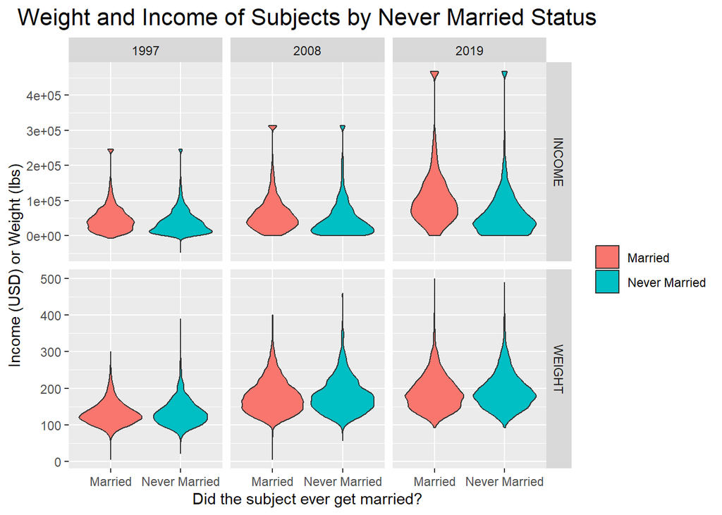

```r
#Select numeric yearly variables and convert to long format for wrapping
nlsy97_int_long <- nlsy97 %>%
  select(starts_with(c('INCOME', 'WEIGHT_')), NEVERMARRY, FAILMARRY) %>%
  pivot_longer(cols = starts_with(c('INCOME', 'WEIGHT_')),
               names_to = 'VARIABLE',
               values_to = 'VALUE') %>%
  separate(VARIABLE, into = c('TYPE', 'YEAR'), sep = '_', remove = FALSE) %>%
  mutate(YEAR = as.factor(YEAR))


#Create a facet grip of violin plots
## Never Married
nlsy97_int_long %>%
  filter(!is.na(NEVERMARRY)) %>%
  ggplot() +
  geom_violin(aes(x = NEVERMARRY, y = VALUE, fill = NEVERMARRY)) +
  facet_grid2(TYPE~YEAR, scales = 'free_y', independent = 'none') +
  scale_x_discrete(labels = c('Married','Never Married')) +
  scale_fill_discrete(labels = c('Married','Never Married')) +
  theme(legend.title = element_blank()) +
  labs(x = 'Did the subject ever get married?', y = 'Income (USD) or Weight (lbs)') +
  ggtitle('Weight and Income of Subjects by Never Married Status') +
  theme(plot.title = element_text(hjust = 0.5, size = 16))
```

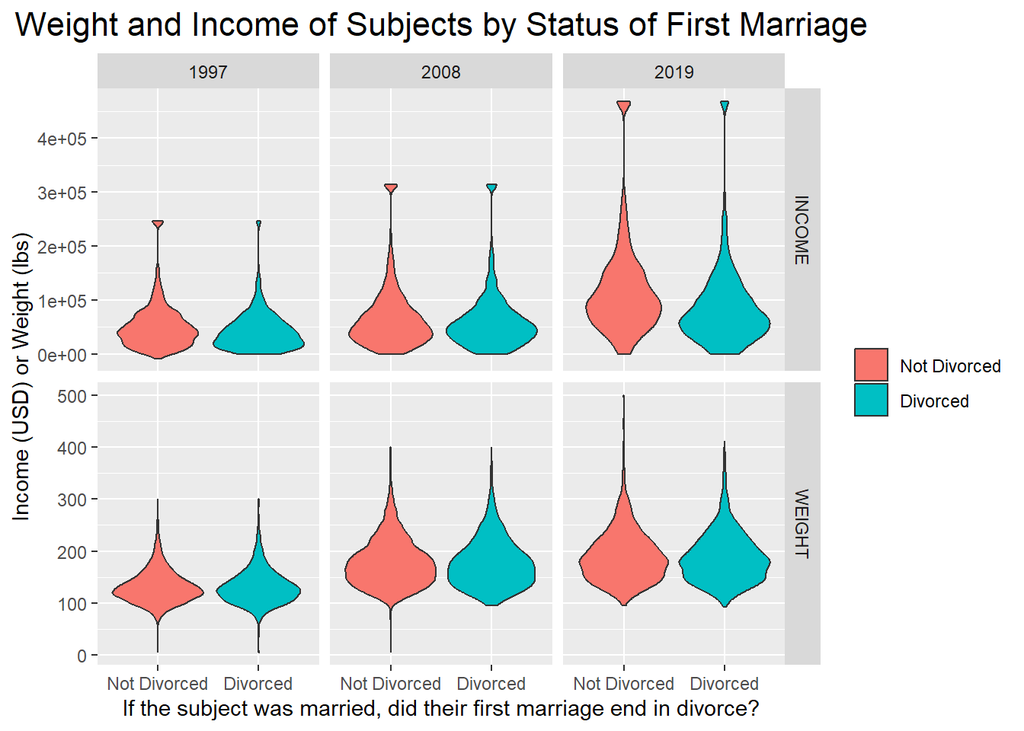

```r
## Failed First Marriage
nlsy97_int_long %>%
  filter(!is.na(FAILMARRY)) %>%
  ggplot() +
  geom_violin(aes(x = FAILMARRY, y = VALUE, fill = FAILMARRY)) +
  facet_grid2(TYPE~YEAR, scales = 'free_y', independent = 'none') +
  scale_x_discrete(labels = c('Not Divorced', 'Divorced')) +
  scale_fill_discrete(labels = c('Not Divorced', 'Divorced')) +
  theme(legend.title = element_blank()) +
  labs(x = 'If the subject was married, did their first marriage end in divorce?',
       y = 'Income (USD) or Weight (lbs)') +
  ggtitle('Weight and Income of Subjects by Status of First Marriage') +
  theme(plot.title = element_text(hjust = 0.5, size = 16))
```

```r
#Floor negative income values
nlsy97$INCOME_1997[nlsy97$INCOME_1997 < 0 & !is.na(nlsy97$INCOME_1997)] <- 0
```

### Factor Variables

Now let’s look at the factor variables for different years. This includes the subject’s perception of their health and weight and their desire to change their weight. As a reminder, the weight factor variables are not available for 2019. I had to rotate the data this way to show the differences in the target variable. Like above, this is a bird’s eye view.

The default fill colors were too similar and made the graph harder to read. Therefore, I found [this blog post](https://www.r-bloggers.com/2013/09/how-to-expand-color-palette-with-ggplot-and-rcolorbrewer/), which shows how to increase the size of a Brewer’s palette to fit the graph’s requirements.The color’s aren’t pretty, in my opinion, but they are distinct.

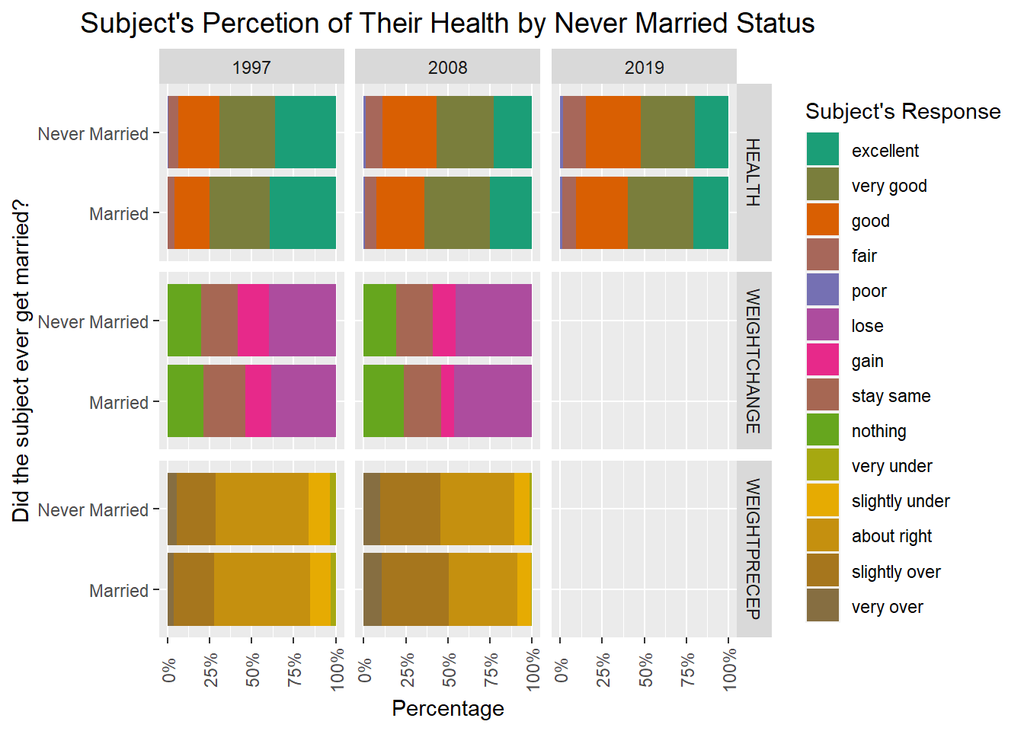

```r
nlsy97_fct_long <- nlsy97 %>%
  select(starts_with(c('HEALTH', 'WEIGHTCHANGE', 'WEIGHTPRECEP')), NEVERMARRY, FAILMARRY) %>%
  pivot_longer(cols = starts_with(c('HEALTH', 'WEIGHTCHANGE', 'WEIGHTPRECEP')),
               names_to = 'VARIABLE',
               values_to = 'VALUE') %>%
  separate(VARIABLE, into = c('TYPE', 'YEAR'), sep = '_', remove = FALSE) %>%
  mutate(YEAR = as.factor(YEAR))

#Create color palette function
colourCount <- length(unique(nlsy97_fct_long$VALUE))
getPalette <- colorRampPalette(brewer.pal(8, "Dark2"))


#Never Married
nlsy97_fct_long %>%
  filter(!is.na(NEVERMARRY) & !is.na(VALUE)) %>%
  ggplot(aes(fill = VALUE, y = NEVERMARRY)) +
  geom_bar(position = 'fill') +
  facet_grid2(TYPE~YEAR, scales = 'free_y') +
  scale_fill_manual(values = getPalette(colourCount), name = "Subject's Response") +
  scale_y_discrete(labels = c('Married','Never Married')) +
  scale_x_continuous(labels = percent) +
  labs(x = 'Percentage', y = "Did the subject ever get married?") +
  ggtitle("Subject's Percetion of Their Health by Never Married Status") +
  theme(plot.title = element_text(hjust = 0.5, size = 14),
        axis.text.x = element_text(angle = 90, vjust = 0.5))
```

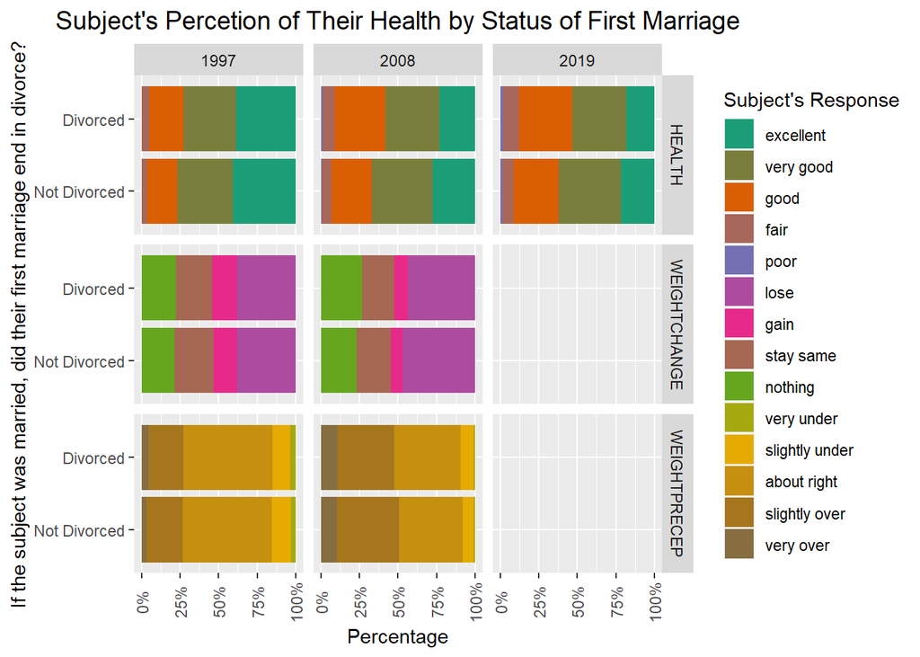

```r
#Failed Marriage
nlsy97_fct_long %>%
  filter(!is.na(FAILMARRY) & !is.na(VALUE)) %>%
  ggplot(aes(fill = VALUE, y = FAILMARRY)) +
  geom_bar(position = 'fill') +
  facet_grid2(TYPE~YEAR, scales = 'free_y') +
  scale_fill_manual(values = getPalette(colourCount), name = "Subject's Response") +
  scale_y_discrete(labels = c('Not Divorced','Divorced')) +
  scale_x_continuous(labels = percent) +
  labs(x = 'Percentage', y = "If the subject was married, did their first marriage end in divorce?") +
  ggtitle("Subject's Percetion of Their Health by Status of First Marriage") +
  theme(plot.title = element_text(hjust = 0.5, size = 14),
        axis.text.x = element_text(angle = 90, vjust = 0.5))
```

The graph shows some interesting insights between the target variables. People that never married or got divorced have a more pessimistic opinion of their health. Subjects that never got married or their first marriage ended in divorce are more likely to say their health is not “excellent” or “very good.” Those that never got married also are more likely to want to change their weight, mostly due to individuals that want to gain weight. However, in their mid-20s, subjects that married before 2019 were more likely to say they are over weight. For the divorce factor, there is no discernible difference between the subjects reported weight goals or perception. This paints a mixed picture but seems to indicate `HEALTH` is the best predictor amount these variables.

## Statistics

Let’s take a quick look at some more statistics for subjects who never married or their first marriage ended in divorce.

### Numeric Variables

```r
nlsy97_num_long2 <- nlsy97 %>%

  #Select factor variables not previously examined
  select(HHSIZE_1998, HEIGHTIN_2008, ASVAB, GRADESREPEAT, GRADESSKIP, HIGHGRADE, WKSWK_ADULT, MARRYAGE, COHABAGE, NEVERMARRY, FAILMARRY) %>%

  #Pivot variables to column
  pivot_longer(cols = -c(NEVERMARRY, FAILMARRY),
               names_to = 'VARIABLE',
               values_to = 'VALUE')

#Find the mean values for each variable of interest
(varmeans <- nlsy97_num_long2 %>%
  group_by(VARIABLE) %>%
  summarize(overall_mean = mean(VALUE, na.rm = TRUE)))
```

```
## # A tibble: 9 × 2
##   VARIABLE      overall_mean
##   <chr>                <dbl>
## 1 ASVAB           45414.
## 2 COHABAGE           22.9
## 3 GRADESREPEAT        0.241
## 4 GRADESSKIP          0.0289
## 5 HEIGHTIN_2008      67.5
## 6 HHSIZE_1998         4.42
## 7 HIGHGRADE          13.9
## 8 MARRYAGE           26.1
## 9 WKSWK_ADULT       598.
```

```r
#Find means by target variable category and compute difference
nlsy97_num_long2 %>%

  #Pivot marital status to column
  pivot_longer(cols = c(NEVERMARRY, FAILMARRY),
               names_to = 'MARRYSTAT',
               values_to = 'MARRYVALUE') %>%

  #Add  the  means to the long data set
  left_join(varmeans, by = 'VARIABLE') %>%

  #Group By
  group_by(MARRYSTAT, MARRYVALUE, VARIABLE, overall_mean) %>%

  #Filter out NA
  filter(!is.na(VALUE) & !is.na(MARRYVALUE)) %>%

  #Find count and mean by the target variable groups
  summarize(count = n(),
            group_mean = mean(as.numeric(as.character(VALUE)), na.rm = TRUE)) %>%

  #Find the percent difference from the overall sort by the largest percent difference
  mutate(pct_diff = (group_mean/overall_mean) - 1) %>%
  arrange(desc(abs(pct_diff)))
```

[output not shown]

```
## # A tibble: 35 × 7
## # Groups:   MARRYSTAT, MARRYVALUE, VARIABLE [35]
##    MARRYSTAT  MARRYVALUE VARIABLE     overall_mean count group_mean pct_diff
##    <chr>      <fct>      <chr>               <dbl> <int>      <dbl>    <dbl>
##  1 FAILMARRY  1          GRADESSKIP         0.0289   941     0.0404    0.395
##  2 NEVERMARRY 1          GRADESREPEAT       0.241   1681     0.326     0.354
##  3 FAILMARRY  0          GRADESREPEAT       0.241   2350     0.163    -0.325
##  4 FAILMARRY  0          GRADESSKIP         0.0289  2324     0.0211   -0.271
##  5 NEVERMARRY 0          GRADESREPEAT       0.241   2866     0.189    -0.215
##  6 NEVERMARRY 0          WKSWK_ADULT      598.      3748   704.        0.176
##  7 FAILMARRY  0          ASVAB          45414.      2712 52411.        0.154
##  8 FAILMARRY  0          WKSWK_ADULT      598.      3068   685.        0.146
##  9 NEVERMARRY 1          ASVAB          45414.      2130 39001.       -0.141
## 10 FAILMARRY  1          MARRYAGE          26.1     1386    23.4      -0.103
## # ℹ 25 more rows
```

This shows some very surprising results. Those that get divorced skip more grades; this seems go against the other academic achievement indicators. However, the expected pattern holds for grades repeated. Those that never marry or get divorced repeat more grades on average. The ASVAB test percentile holds with the trends for academic achievement. Those that don’t get divorced see the ASVAB percentile 15.4% higher than the overall group, while those that never get married have scores 14.1% lower than the overall sample. The average marriage age for subjects that get divorced is 10.3% lower than the overall for the population. Interestingly, there is no significant difference in height for the mean groups.

### Factor Variables

```r
nlsy97 %>%

  #Select factor variables not previously examined
  select(RACE, FEMALE, BOTHPARENTS_1997, GED, HS, AA, BA, PROF, MA, COHAB_PREMARRY, NEVERMARRY, FAILMARRY) %>%

  #Pivot variables to column
  pivot_longer(cols = -c(NEVERMARRY, FAILMARRY),
               names_to = 'VARIABLE',
               values_to = 'VALUE') %>%

  #Pivot marital status to column
  pivot_longer(cols = c(NEVERMARRY, FAILMARRY),
               names_to = 'MARRYSTAT',
               values_to = 'MARRYVALUE') %>%

  #Group By
  group_by(MARRYSTAT, VARIABLE, VALUE) %>%

  #Filter out NA
  filter(!is.na(VALUE) & !is.na(MARRYVALUE)) %>%

  #Find count and pct true for  the target variable
  summarize(count = sum(as.numeric(as.character(MARRYVALUE))),
            pct_true = mean(as.numeric(as.character(MARRYVALUE)), na.rm = TRUE)) %>%

  #Find the difference from the overall percent true and sort by the largest absolute difference
  mutate(diff = case_when(MARRYSTAT == 'FAILMARRY' ~ pct_true - as.numeric(div_true_overall),
                          MARRYSTAT == 'NEVERMARRY' ~ pct_true - as.numeric(nm_true_overall)),
         absdiff = abs(diff)) %>%
  arrange(desc(absdiff))
```

```
## # A tibble: 44 × 7
## # Groups:   MARRYSTAT, VARIABLE [20]
##    MARRYSTAT  VARIABLE VALUE                    count pct_true   diff absdiff
##    <chr>      <chr>    <fct>                    <dbl>    <dbl>  <dbl>   <dbl>
##  1 NEVERMARRY RACE     black                     1103    0.600  0.202   0.202
##  2 NEVERMARRY PROF     1                           22    0.218 -0.180   0.180
##  3 FAILMARRY  PROF     1                           14    0.152 -0.142   0.142
##  4 NEVERMARRY MA       1                          151    0.257 -0.141   0.141
##  5 FAILMARRY  MA       1                           75    0.159 -0.136   0.136
##  6 FAILMARRY  GED      1                          220    0.419  0.125   0.125
##  7 FAILMARRY  HS       0                          369    0.416  0.121   0.121
##  8 NEVERMARRY BA       1                          558    0.286 -0.112   0.112
##  9 NEVERMARRY HS       0                          760    0.508  0.110   0.110
## 10 NEVERMARRY RACE     non-black & non-hispanic  1010    0.291 -0.107   0.107
## # ℹ 34 more rows
```

The data shows some interesting insights. First, I found some issues in my variable noting of the subject lived a partner before they got married, so I had to spend time back in the data cleaning file correcting that issue. The largest difference is by race. Back subjects are 20 points more likely to never marry than the population average. Those with professional and Master’s degrees are more likely to marry and less likely to get divorces than the sample’s average. Those with a GED or without a high school diploma get divorced at a rate 12 points high than the overall sample. Those with a Bachelor’s degree are more likely to get married, while those without a high school degree are less likely to do the same. This data disproves my hypothesis that those with more education are less likely to get married. Instead, it shows that those with more education get and stay married. The stratification by race also is unexpected.

## Getting Ready to Model

Logistic regression assumes that each column in independent. Therefore, we need to test for multicolinearity before proceeding with modeling. This can be done visually for the numeric variables using a correlation plot.

```r
cormatrix <- cor(select_if(nlsy97[,2:36], is.numeric), use = 'complete.obs')

cormatrix
```

```
##                 WEIGHT_1997 INCOME_1997  HHSIZE_1998       ASVAB  INCOME_2008
## WEIGHT_1997    1.000000e+00 -0.05156015 -0.087801819 -0.04418435 -0.038949619
## INCOME_1997   -5.156015e-02  1.00000000  0.033480517  0.30050054  0.183556736
## HHSIZE_1998   -8.780182e-02  0.03348052  1.000000000 -0.10986417  0.026809415
## ASVAB         -4.418435e-02  0.30050054 -0.109864170  1.00000000  0.075178888
## INCOME_2008   -3.894962e-02  0.18355674  0.026809415  0.07517889  1.000000000
## WEIGHT_2008    7.011933e-01 -0.09879414 -0.014414056 -0.06624140 -0.081329679
## INCOME_2019   -2.189736e-02  0.31064061 -0.018454423  0.29315521  0.227280467
## WEIGHT_2019    6.489542e-01 -0.10154971 -0.001993624 -0.08420550 -0.064079456
## GRADESREPEAT  -5.405372e-05 -0.15580453  0.004849682 -0.30819625 -0.076060026
## GRADESSKIP     3.125304e-02  0.02595837  0.032021558  0.04888674  0.045292635
## WKSWK_ADULT    1.814276e-01  0.08746997 -0.068154311  0.10224110  0.139896067
## HIGHGRADE     -9.859702e-02  0.19434837 -0.076902481  0.35811865  0.060610978
## HEIGHTIN_2008  3.395056e-01  0.05707392  0.002384729  0.03623017 -0.053346930
## MARRYAGE       3.460231e-02  0.14690674 -0.047113618  0.12916200 -0.005822665
## COHABAGE      -1.279420e-02  0.26937817  0.002625723  0.22083184  0.109322309
##                WEIGHT_2008 INCOME_2019  WEIGHT_2019  GRADESREPEAT   GRADESSKIP
## WEIGHT_1997    0.701193290 -0.02189736  0.648954181 -5.405372e-05  0.031253038
## INCOME_1997   -0.098794138  0.31064061 -0.101549706 -1.558045e-01  0.025958368
## HHSIZE_1998   -0.014414056 -0.01845442 -0.001993624  4.849682e-03  0.032021558
## ASVAB         -0.066241405  0.29315521 -0.084205498 -3.081962e-01  0.048886736
## INCOME_2008   -0.081329679  0.22728047 -0.064079456 -7.606003e-02  0.045292635
## WEIGHT_2008    1.000000000 -0.09104454  0.855459659  8.644712e-03  0.040531102
## INCOME_2019   -0.091044540  1.00000000 -0.126311744 -1.632724e-01  0.010911345
## WEIGHT_2019    0.855459659 -0.12631174  1.000000000 -1.425830e-02  0.042640920
## GRADESREPEAT   0.008644712 -0.16327240 -0.014258299  1.000000e+00  0.053150550
## GRADESSKIP     0.040531102  0.01091135  0.042640920  5.315055e-02  1.000000000
## WKSWK_ADULT    0.122592223  0.11890273  0.113213986 -8.063123e-02 -0.009979549
## HIGHGRADE     -0.155705038  0.26065996 -0.155863564 -2.406036e-01  0.021437377
## HEIGHTIN_2008  0.475874852  0.04775387  0.462001761  3.491308e-02 -0.025308522
## MARRYAGE       0.028616206  0.12960886  0.032167137  1.410614e-02  0.025665381
## COHABAGE       0.012497266  0.23667761  0.016075257 -8.607599e-02  0.003856864
##                WKSWK_ADULT   HIGHGRADE HEIGHTIN_2008     MARRYAGE     COHABAGE
## WEIGHT_1997    0.181427569 -0.09859702   0.339505568  0.034602314 -0.012794198
## INCOME_1997    0.087469967  0.19434837   0.057073916  0.146906745  0.269378174
## HHSIZE_1998   -0.068154311 -0.07690248   0.002384729 -0.047113618  0.002625723
## ASVAB          0.102241099  0.35811865   0.036230171  0.129161995  0.220831844
## INCOME_2008    0.139896067  0.06061098  -0.053346930 -0.005822665  0.109322309
## WEIGHT_2008    0.122592223 -0.15570504   0.475874852  0.028616206  0.012497266
## INCOME_2019    0.118902732  0.26065996   0.047753871  0.129608863  0.236677606
## WEIGHT_2019    0.113213986 -0.15586356   0.462001761  0.032167137  0.016075257
## GRADESREPEAT  -0.080631227 -0.24060362   0.034913079  0.014106139 -0.086075991
## GRADESSKIP    -0.009979549  0.02143738  -0.025308522  0.025665381  0.003856864
## WKSWK_ADULT    1.000000000  0.10390893   0.159622908  0.090915728  0.125765201
## HIGHGRADE      0.103908928  1.00000000  -0.094080204  0.124852167  0.188792664
## HEIGHTIN_2008  0.159622908 -0.09408020   1.000000000  0.185342563  0.146083458
## MARRYAGE       0.090915728  0.12485217   0.185342563  1.000000000  0.630271018
## COHABAGE       0.125765201  0.18879266   0.146083458  0.630271018  1.000000000
```

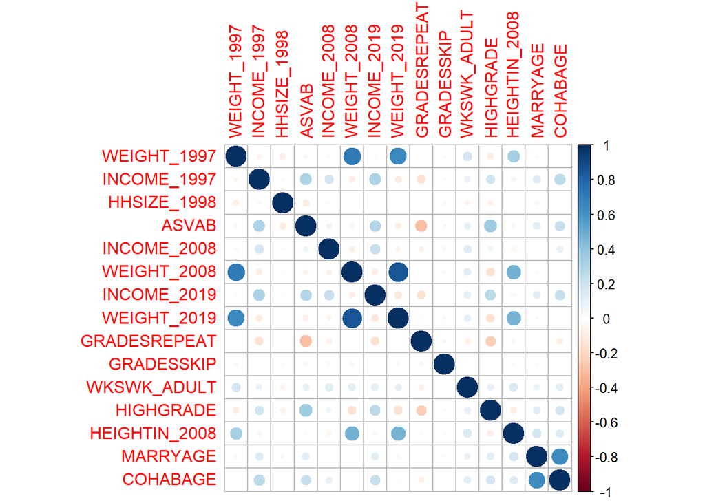

```r
corrplot(cormatrix)
```

## Next File

**Let’s save the data file with any changes and move to the next and final markdown document.**

```r
saveRDS(nlsy97, 'Data/clean2_nlsy97.Rds')
```